# (Almost) Fully Customisable Choropleth Maps

## 6.2 viridis

This package brings to R, color scales created by Stéfan van der Walt and Nathaniel Smith for the Python matplotlib library. We can use the colour scales in this package to make plots that are “pretty, better represent your data, easier to read by those with colorblindness, and print well in grey scale”.

More information here: https://cran.r-project.org/web/packages/viridis/vignettes/intro-to-viridis.html

Here we’ll use the function `scale_fill_viridis()` to call the palette:

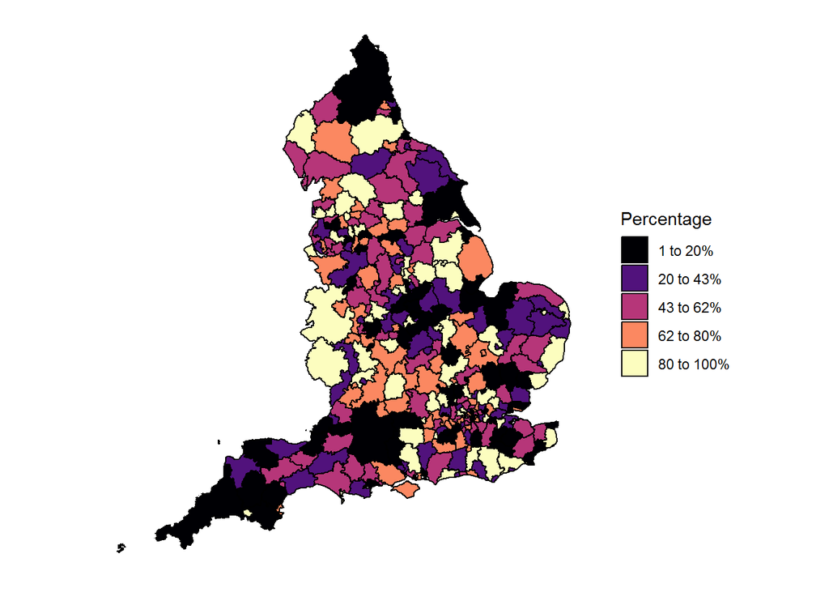

```r
ggplot() +
  geom_polygon(data = map_data,
               aes(x = long, y = lat, group = group,
                   fill = cut(x = Percentage, n = 5, breaks = jenks_breaks$brks,
                              labels = labels, include.lowest = TRUE)),
               col = "black") +
  coord_equal()+
  theme_map +
  scale_fill_viridis(option = "magma", discrete = TRUE, name = "Percentage")
```

But maybe you don’t want to use one of these lovely pre-defined palettes and you want to define the colours yourself. You can do this using `scale_fill_manual()` and define the colours as your values:

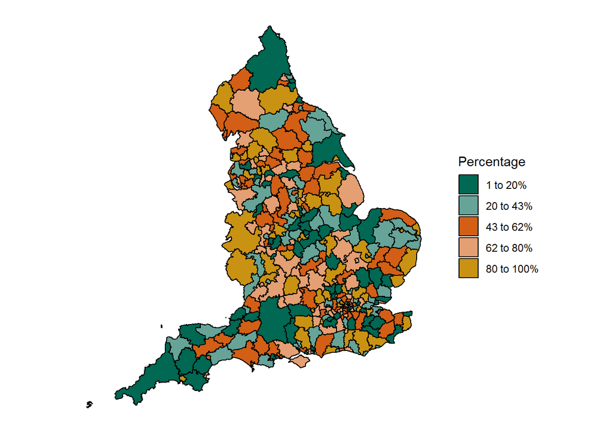

```r
dft_colours <- c("#006853", #dark green
                 "#66a498", # green
                 "#d25f15", #orange
                 "#e49f73", #light orange
                 "#c99212") #yellow


ggplot() +
  geom_polygon(data = map_data,
               aes(x = long, y = lat, group = group,
                   fill = cut(x = Percentage, n = 5, breaks = jenks_breaks$brks,
                              labels = labels, include.lowest = TRUE)),
               col = "black") +
  coord_equal()+
  theme_map +
  scale_fill_manual(values = dft_colours, name = "Percentage")
```

# 7 Customise even further….

There are a bunch of other things we can do to customise our map even further.

We can add a title and caption:

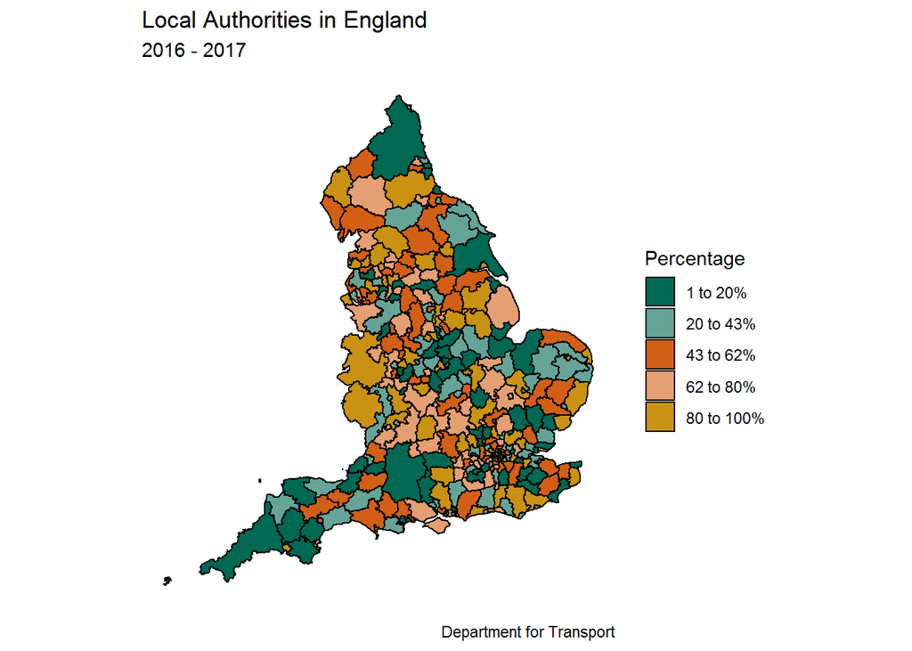

```r
ggplot() +
  geom_polygon(data = map_data,
               aes(x = long, y = lat, group = group,
                   fill = cut(x = Percentage, n = 5, breaks = jenks_breaks$brks,
                              labels = labels, include.lowest = TRUE)),
               col = "black") +
  coord_equal()+
  theme_map +
  scale_fill_manual(values = dft_colours, name = "Percentage")+
  labs(x = NULL,
       y = NULL,
       title = "Local Authorities in England",
       subtitle = "2016 - 2017",
       caption = "Department for Transport")
```

We can add to the theme to change the style of text:

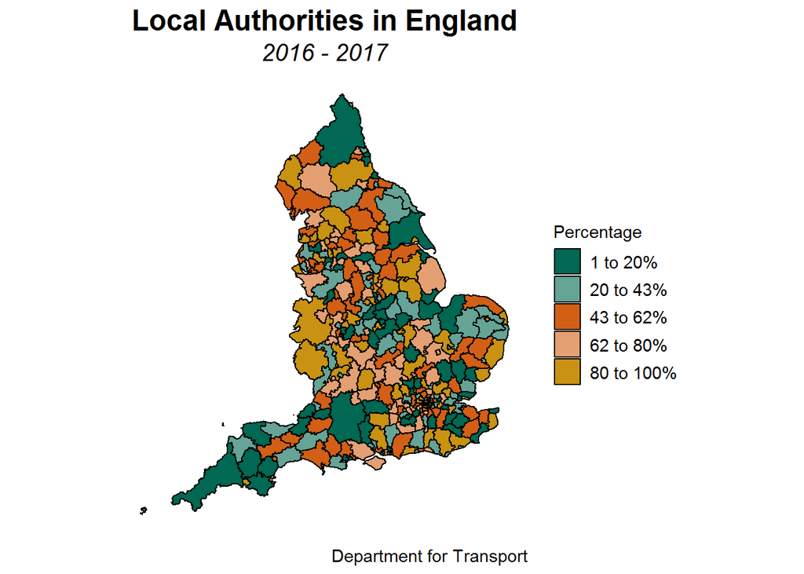

```r
ggplot() +
  geom_polygon(data = map_data,
               aes(x = long, y = lat, group = group,
                   fill = cut(x = Percentage, n = 5, breaks = jenks_breaks$brks,
                              labels = labels, include.lowest = TRUE)),
               col = "black") +
  coord_equal()+
  theme_map +
  scale_fill_manual(values = dft_colours, name = "Percentage")+
  labs(x = NULL,
       y = NULL,
       title = "Local Authorities in England",
       subtitle = "2016 - 2017",
       caption = "Department for Transport")+
  theme(plot.title = element_text(hjust = 0.5, size = 18, face = "bold"),
        plot.subtitle = element_text(hjust = 0.5, size = 15, face = "italic"),
        plot.caption = element_text(size = 11),
        legend.title = element_text(size = 11),
        legend.text = element_text(size = 11))
```

We can do various things to the legend.

We can change the width and height of the legend categories:

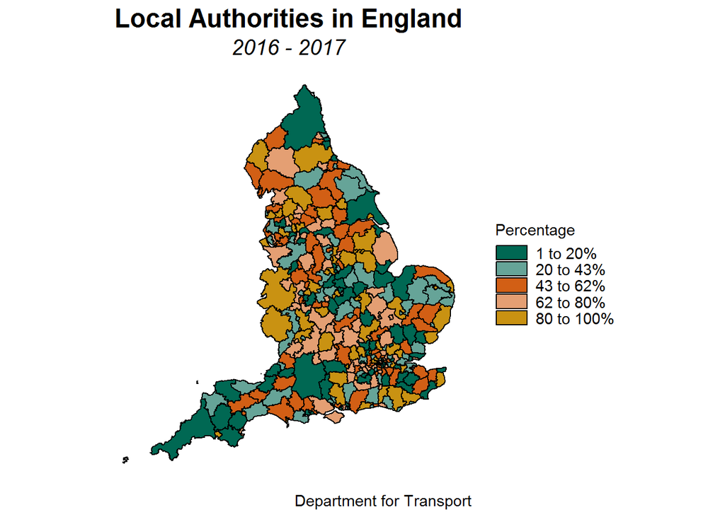

```r
ggplot() +
  geom_polygon(data = map_data,
               aes(x = long, y = lat, group = group,
                   fill = cut(x = Percentage, n = 5, breaks = jenks_breaks$brks,
                              labels = labels, include.lowest = TRUE)),
               col = "black") +
  coord_equal()+
  theme_map +
  scale_fill_manual(values = dft_colours, name = "Percentage",
                    guide = guide_legend(keyheight = unit(4, units = "mm"),
                                         keywidth = unit(8, units = "mm")))+
  labs(x = NULL,
       y = NULL,
       title = "Local Authorities in England",
       subtitle = "2016 - 2017",
       caption = "Department for Transport")+
  theme(plot.title = element_text(hjust = 0.5, size = 18, face = "bold"),
        plot.subtitle = element_text(hjust = 0.5, size = 15, face = "italic"),
        plot.caption = element_text(size = 11),
        legend.title = element_text(size = 11),
        legend.text = element_text(size = 11))
```

We can make it horizontal and put it at the bottom:

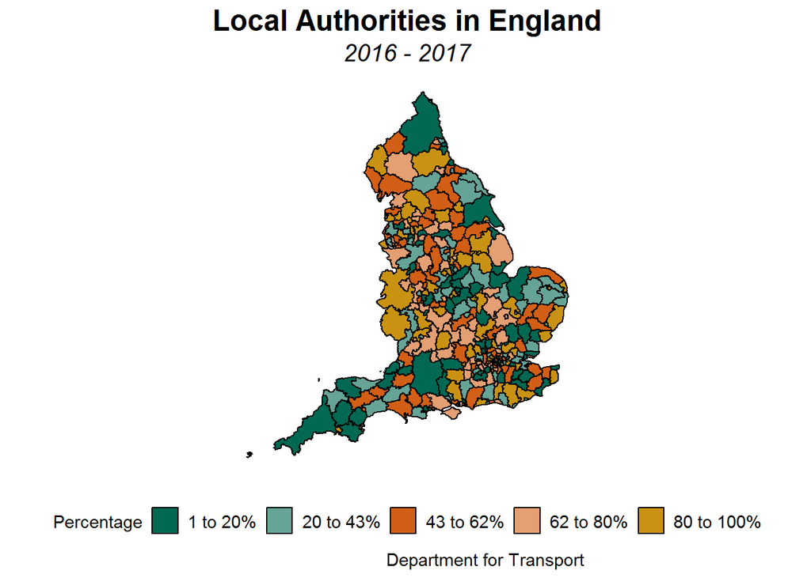

```r
ggplot() +
  geom_polygon(data = map_data,
               aes(x = long, y = lat, group = group,
                   fill = cut(x = Percentage, n = 5, breaks = jenks_breaks$brks,
                              labels = labels, include.lowest = TRUE)),
               col = "black") +
  coord_equal()+
  theme_map +
  scale_fill_manual(values = dft_colours, name = "Percentage",
                    guide = guide_legend(direction = "horizontal"))+
  labs(x = NULL,
       y = NULL,
       title = "Local Authorities in England",
       subtitle = "2016 - 2017",
       caption = "Department for Transport")+
  theme(plot.title = element_text(hjust = 0.5, size = 18, face = "bold"),
        plot.subtitle = element_text(hjust = 0.5, size = 15, face = "italic"),
        plot.caption = element_text(size = 11),
        legend.title = element_text(size = 11),
        legend.text = element_text(size = 11),
        legend.position = "bottom")
```

We can change the position of the legend more precisely using coordinates within the theme:

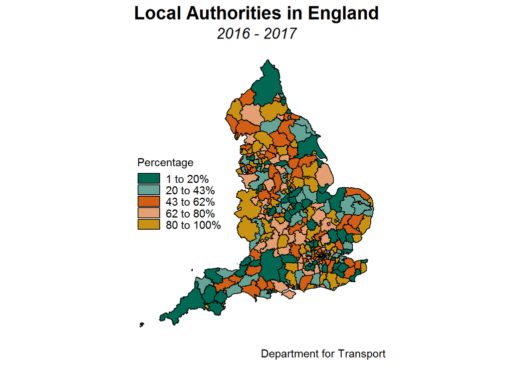

```r
map2 <- ggplot() +
  geom_polygon(data = map_data,
               aes(x = long, y = lat, group = group,
                   fill = cut(x = Percentage, n = 5, breaks = jenks_breaks$brks,
                              labels = labels, include.lowest = TRUE)),
               col = "black") +
  coord_equal()+
  theme_map +
  scale_fill_manual(values = dft_colours, name = "Percentage",
                    guide = guide_legend(keyheight = unit(4, units = "mm"),
                                         keywidth = unit(8, units = "mm")))+
  labs(x = NULL,
       y = NULL,
       title = "Local Authorities in England",
       subtitle = "2016 - 2017",
       caption = "Department for Transport")+
  theme(plot.title = element_text(hjust = 0.5, size = 18, face = "bold"),
        plot.subtitle = element_text(hjust = 0.5, size = 15, face = "italic"),
        plot.caption = element_text(size = 11),
        legend.title = element_text(size = 11),
        legend.text = element_text(size = 11),
        legend.position = c(0.2,0.5))

map2
```

We can label the local authorities…

First summarise the data to get mean latitude and mean longitude for each LA

```r
LA_labels <- map_data %>%
  group_by(Local_Authority) %>%
  summarise_at(vars(long, lat), mean)

head(LA_labels)
```

```
## # A tibble: 6 x 3
##   Local_Authority    long     lat
##   <chr>             <dbl>   <dbl>
## 1 Adur            519182. 106774.
## 2 Allerdale       322813. 535915.
## 3 Amber Valley    435629. 348353.
## 4 Arun            500759. 106234.
## 5 Ashfield        449089. 354446.
## 6 Ashford         596184. 139706.
```

Then we’ll add the labels using `geom_text()`

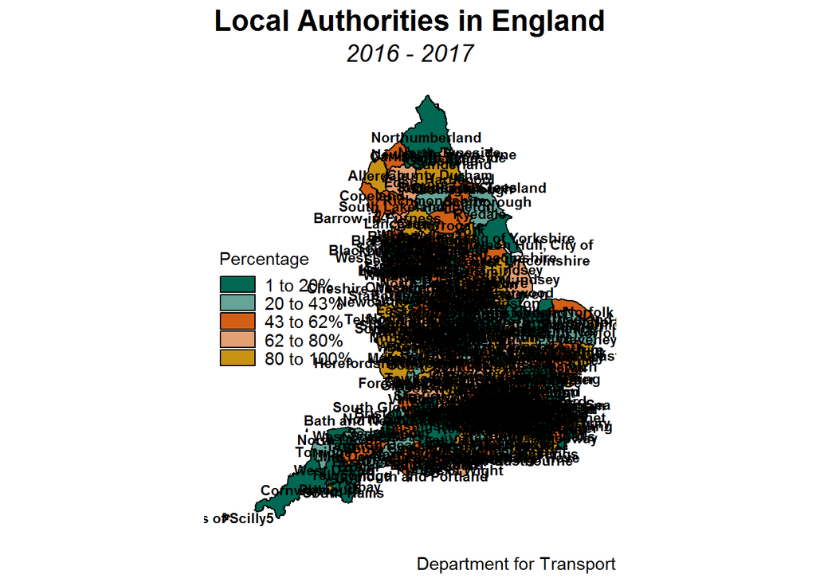

```r
map2 + geom_text(data=LA_labels, aes(long, lat, label = Local_Authority), size=3, fontface="bold")
```

With 326 local authorities, plotting them all at once isn’t a great idea. Instead we can choose a subset of LA labels to plot:

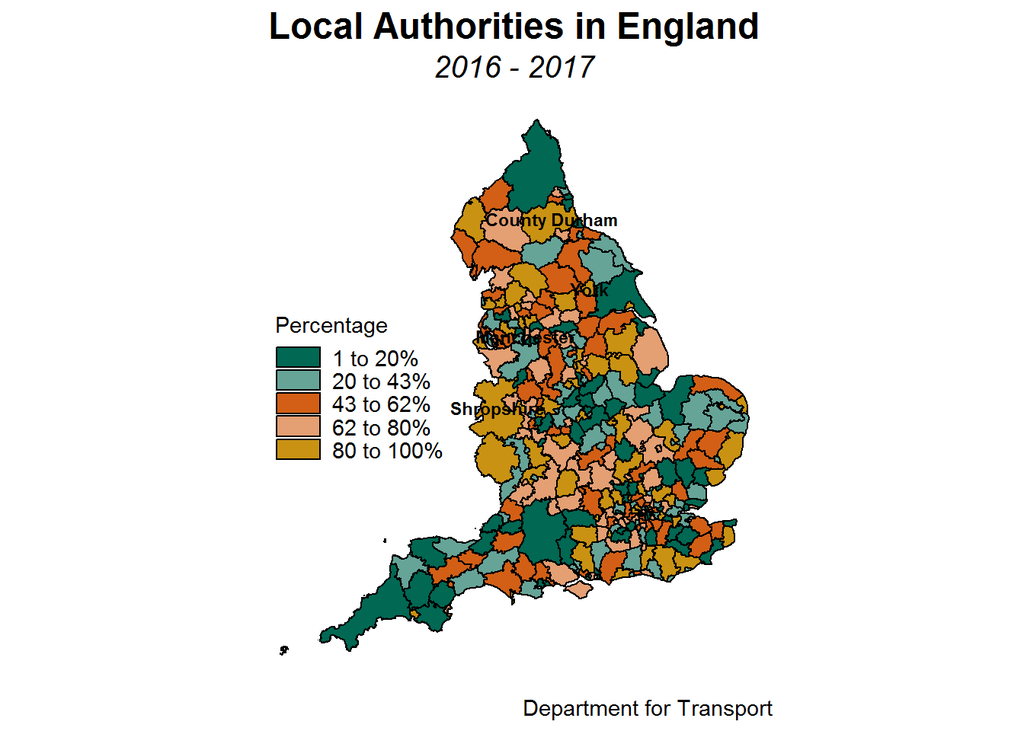

```r
LA_labels_selected <- LA_labels %>%
  filter(Local_Authority %in% c("Manchester", "Shropshire", "York", "County Durham"))

map2 + geom_text(data=LA_labels_selected, aes(long, lat, label = Local_Authority), size=3, fontface="bold")
```

Still not very clear. Let’s make them into actual labels instead:

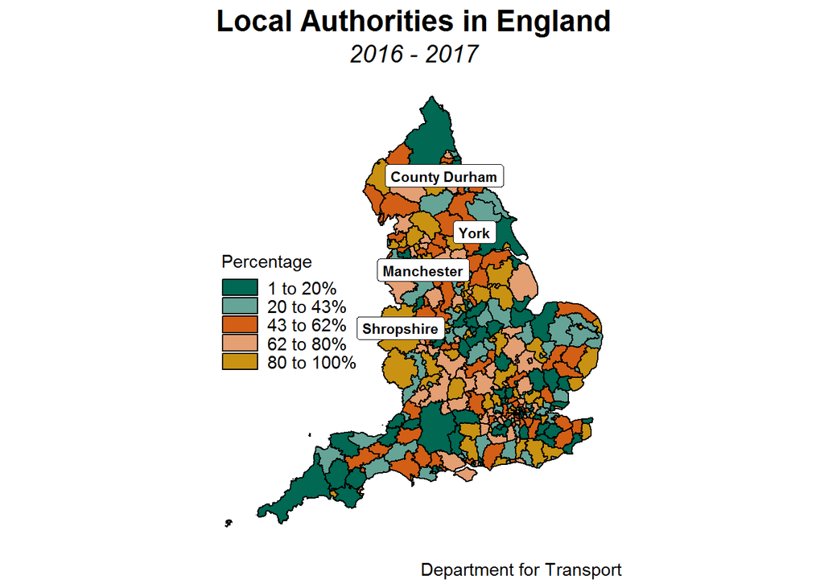

```r
map2 + geom_label(data=LA_labels_selected, aes(long, lat, label = Local_Authority), size=3, fontface="bold")
```

The labels cover up the area on the map so lets make them more transparent with alpha:

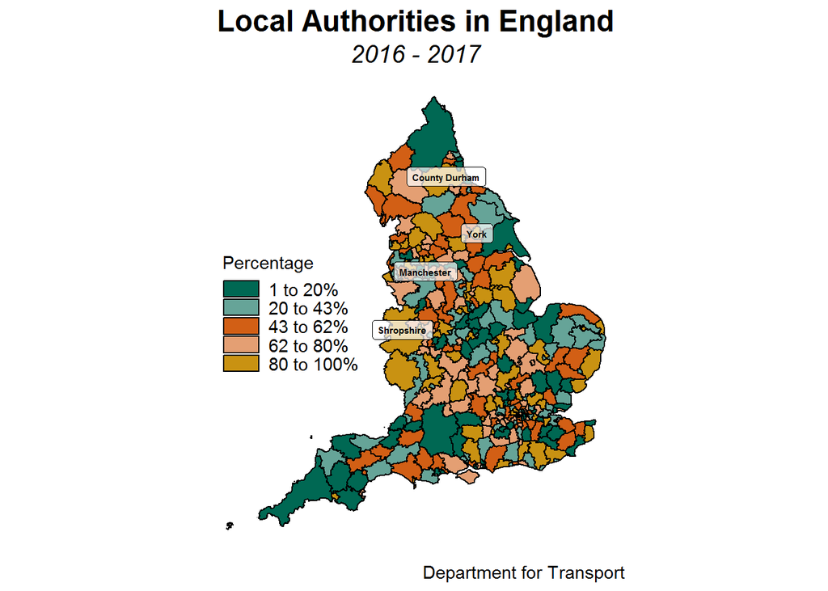

```r
# can change the transparency
map2 +
  geom_label(data=LA_labels_selected, aes(long, lat, label = Local_Authority), alpha= 0.7, size=2, fontface="bold")
```